# Prediction Assignment

Paul Loh

16 July 2017

## Problem Definition

From a given data set of sensor information relating to bicep curl excercises investigate what features (variables) and model would be most accurate in predicting whether the same excercise is being preformed correctly with a new set of similar data. The *classe* variable identifies whether the excercise is being performed correctly contains the following values:

- Class A: Exactly according to the specification
- Class B: Throwing the elbows to the front
- Class C: Lifting the dumbbell only halfway
- Class D: Lowering the dumbbell only halfway
- Class E: Throwing the hips to the front

Read more: http://groupware.les.inf.puc-rio.br/har#ixzz4mS9ozCkG

## Preparation

```r
  library(doParallel); library(caret); library(ggplot2); library(gridExtra); library(stringr); library(reshape); library(Hmisc); library(scatterplot3d); library(MASS); library(gbm); library(randomForest)
```

### Load Data

```r
  # Clear down everything
  rm(list=ls())
  tmpdata <- read.csv2(file='./Data/pml-training.csv', header=TRUE, sep=',', strip.white=TRUE, na.strings='<NA>', stringsAsFactors = FALSE)
  dim(tmpdata)
```

```
## [1] 19622   160
```

As the call to the *dim()* function shows there are a lot of variables to initially consider.

```r
  defs <- as.data.frame(sapply(tmpdata, class))
  names(defs)[1] <- 'Type'
  defs$Name <- rownames(defs)
  defs <- data.frame(defs$Name, defs$Type)
  colrows <- as.integer(nrow(defs) / 3)
  start1<-1; end1<-colrows; start2<-end1+1; end2<-end1+colrows; start3<-end2+1; end3<-nrow(defs)
```

```
##               defs.Name defs.Type
## 1                     X   integer
## 2             user_name character
## 3  raw_timestamp_part_1   integer
## 4  raw_timestamp_part_2   integer
## 5        cvtd_timestamp character
## 6            new_window character
## 7            num_window   integer
## 8             roll_belt character
## 9            pitch_belt character
## 10             yaw_belt character
## 11     total_accel_belt   integer
## 12   kurtosis_roll_belt character
## 13  kurtosis_picth_belt character
## 14    kurtosis_yaw_belt character
```

[output cut: 39 more lines]

```
##                    defs.Name defs.Type
## 54             avg_pitch_arm character
## 55          stddev_pitch_arm character
## 56             var_pitch_arm character
## 57               avg_yaw_arm character
## 58            stddev_yaw_arm character
## 59               var_yaw_arm character
## 60               gyros_arm_x character
## 61               gyros_arm_y character
## 62               gyros_arm_z character
## 63               accel_arm_x   integer
## 64               accel_arm_y   integer
## 65               accel_arm_z   integer
## 66              magnet_arm_x   integer
## 67              magnet_arm_y   integer
```

[output cut: 39 more lines]

```
##                   defs.Name defs.Type
## 107      avg_pitch_dumbbell character
## 108   stddev_pitch_dumbbell character
## 109      var_pitch_dumbbell character
## 110        avg_yaw_dumbbell character
## 111     stddev_yaw_dumbbell character
## 112        var_yaw_dumbbell character
## 113        gyros_dumbbell_x character
## 114        gyros_dumbbell_y character
## 115        gyros_dumbbell_z character
## 116        accel_dumbbell_x   integer
## 117        accel_dumbbell_y   integer
## 118        accel_dumbbell_z   integer
## 119       magnet_dumbbell_x   integer
## 120       magnet_dumbbell_y   integer
```

[output cut: 40 more lines]

## Data Pre-processing

### Change Data Types

Some variables have been assigned the wrong data type of character so convert them to numeric.

```r
  excluded <- c(1,2,3,4,5,6,7,160)
  for (i in 1:ncol(tmpdata)) {if(max(i==excluded) == 0) {tmpdata[,i] <- as.numeric(tmpdata[,i])}}
```

### Remove Summary Data Rows

Remove the summary rows form the main data set as these would distort later prediction models.

```r
  summarydata <- subset(tmpdata, new_window=='yes'); tmpdata <- subset(tmpdata, new_window=='no')
```

### Handle Missing Values

The data set now contains many variables with NA values in every observation that can safely be removed:

```r
  summaryNA <- as.data.frame(summary(is.na(tmpdata)))
  summaryNA <- subset(summaryNA, grepl("^(?!Mode|NA).*$", Freq, perl = TRUE))
  summaryNA <- transform(summaryNA, Freq=colsplit(Freq, split=":", names=c('Exists', 'Count')))
  summaryNA$Exists <- summaryNA$Freq$Exists;
  summaryNA$Count <- summaryNA$Freq$Count
  allNAcols <- subset(summaryNA, summaryNA$Exists==TRUE & summaryNA$Count==nrow(tmpdata))$Var2
  writeLines(paste('Number of variables all NA = ', as.character(length(allNAcols)), '\n'))
```

```
## Number of variables all NA =  100
```

```r
  tmpdata <- tmpdata[, !(names(tmpdata) %in% allNAcols)]
  dim(tmpdata)
```

```
## [1] 19216    60
```

Removing these variables has significantly reduced the width of the data set from 160 to 60 variables.

### Check Remaining Variables for Near Zero Variance

Remaining variables that have contain variance should be removed as modelling features as they have no impact on the outcome:

```r
  nearZeroVarCols <- nearZeroVar(tmpdata, saveMetrics = TRUE)
  subset(nearZeroVarCols, nearZeroVarCols$zeroVar==TRUE)
```

```
##            freqRatio percentUnique zeroVar  nzv
## new_window         0   0.005203997    TRUE TRUE
```

Remove zero variance variables:

```r
  tmpdata <- tmpdata[, !names(tmpdata) %in% row.names(subset(nearZeroVarCols, nearZeroVarCols$zeroVar==TRUE))]
```

### Remove the Totals Columns

The Totals columns in the data contain subtotals of periods of excercise for each subject. These need to be removed to prevent distortion of modelling predictions i.e. these observations are not of the same type as the data remaining:

```r
  TotalCols <- subset(names(tmpdata), grepl("^total", names(tmpdata), perl = TRUE))
  tmpdata <- tmpdata[, !(names(tmpdata) %in% TotalCols)]
```

### Set classe Variable (the outcome) to a Factor Variable

```r
  tmpdata$classe <- as.factor(tmpdata$classe)
  # Re-order so A is last lever (correct approach) so that we can show on-top in plots?
  levels(tmpdata$classe) <- c('A','B','C','D','E')
```

### Further Preprocessing

#### Check for Remaining NA Values

```r
  if (max(is.na(tmpdata)) > 0) { tmpdata[is.na(tmpdata)] <- 0 }; max(is.na(tmpdata))
```

```
## [1] 0
```

#### Tag Each Row With its Colour According to Classe for Plotting:

- Class A: Exactly according to the specification = Yellow
- Class B: Throwing the elbows to the front = Orange
- Class C: Lifting the dumbbell only halfway = Blue
- Class D: Lowering the dumbbell only halfway = Green
- Class E: Throwing the hips to the front = Pink

```r
  classecols <- c('#F0E442','#E69F00','#56B4E9','#009E73','#CC79A7')
  tmpdata$pColour[tmpdata$classe=='A'] <- classecols[1]
  tmpdata$pColour[tmpdata$classe=='B'] <- classecols[2]
  tmpdata$pColour[tmpdata$classe=='C'] <- classecols[3]
  tmpdata$pColour[tmpdata$classe=='D'] <- classecols[4]
  tmpdata$pColour[tmpdata$classe=='E'] <- classecols[5]
```

## Split Data into Training, Validation and Test Datasets

Large data set so we can divide the data into 60% Training, 20% Validation and 20% Testing

```r
  set.seed(666)
  # 60% Training
  inTrain <- createDataPartition(tmpdata$classe, times=1, p=0.6, list=FALSE)
  training <- tmpdata[inTrain,]
  other <- tmpdata[-inTrain,]
  # 20% Validation and 20% Testing
  inTest <- createDataPartition(other$classe, times=1, p=0.5, list=FALSE)
  testing <- other[inTest,]
  validation <- other[-inTest,]
  rm(other); rm(inTest)
```

Dividing the data along these % ratios results in the following row & column counts:

```
##             [,1] [,2]
## Training   11532   56
## Testing     3843   56
## Validation  3841   56
```

## Exploratory Data Analysis on the Training Set

### 3D Variable Plots

#### Accelerometer Positions

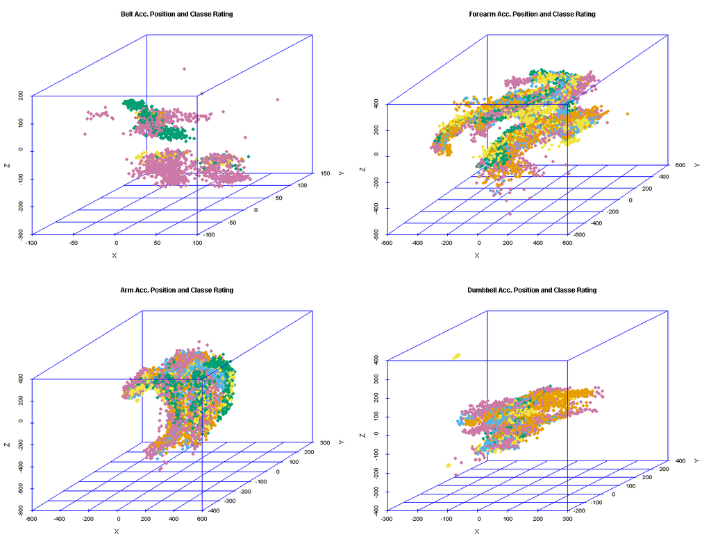

```r
  par(mfrow=c(2,2))
  cols <- c('classe', 'pColour', 'accel_belt_x', 'accel_belt_y', 'accel_belt_z')
  g.accel.belt <- with(training[, cols], scatterplot3d(x=accel_belt_x, y=accel_belt_y, z=accel_belt_z, color=pColour, col.axis = 'blue', col.grid = 'blue', pch=19,main="Belt Acc. Position and Classe Rating",xlab="X", ylab='Y',zlab='Z', cex.symbols = 1.25))

  cols <- c('classe', 'pColour', 'accel_forearm_x', 'accel_forearm_y', 'accel_forearm_z')
  g.accel.forearm <- with(training[, cols], scatterplot3d(x=accel_forearm_x, y=accel_forearm_y, z=accel_forearm_z, color=pColour, col.axis = 'blue', col.grid = 'blue', pch=19,main="Forearm Acc. Position and Classe Rating", xlab="X", ylab='Y',zlab='Z', cex.symbols = 1.25
                                        ))
  cols <- c('classe', 'pColour', 'accel_arm_x', 'accel_arm_y', 'accel_arm_z')
  g.accel.arm <- with(training[, cols], scatterplot3d(x=accel_arm_x, y=accel_arm_y, z=accel_arm_z, color=pColour, col.axis = 'blue', col.grid = 'blue', pch=19, main="Arm Acc. Position and Classe Rating", xlab="X", ylab='Y',zlab='Z', cex.symbols = 1.25))

  cols <- c('classe', 'pColour', 'accel_dumbbell_x', 'accel_dumbbell_y', 'accel_dumbbell_z')
  g.accel.dumbbell <- with(training[, cols], scatterplot3d(x=accel_dumbbell_x, y=accel_dumbbell_y, z=accel_dumbbell_z, color=pColour, col.axis = 'blue', col.grid = 'blue', pch=19, main="Dumbbell Acc. Position and Classe Rating", xlab="X", ylab='Y',zlab='Z', cex.symbols = 1.25))
```

#### Accelerometer Roll, Pitch & Yaw

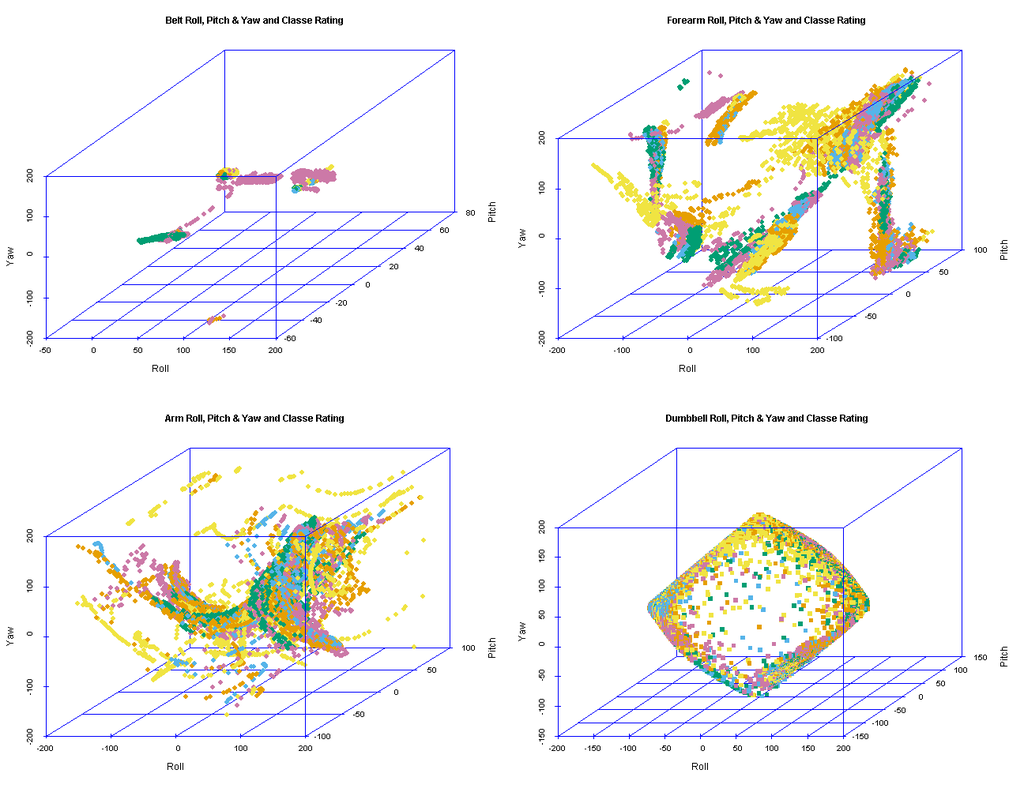

```r
  par(mfrow=c(2,2))
  cols <- c('classe', 'pColour', 'roll_belt', 'pitch_belt', 'yaw_belt')
  g.rpy.belt <- with(training[, cols], scatterplot3d(x=roll_belt, y=pitch_belt, z=yaw_belt, color=pColour, col.axis = 'blue', col.grid = 'blue', pch=19, main="Belt Roll, Pitch & Yaw and Classe Rating", xlab='Roll', ylab='Pitch',zlab='Yaw', cex.symbols = 1.25))

  cols <- c('classe', 'pColour', 'roll_forearm', 'pitch_forearm', 'yaw_forearm')
  g.rpy.forearm <- with(training[, cols], scatterplot3d(x=roll_forearm, y=pitch_forearm, z=yaw_forearm, color=pColour, col.axis = 'blue', col.grid = 'blue', pch=19, main="Forearm Roll, Pitch & Yaw and Classe Rating", xlab='Roll', ylab='Pitch',zlab='Yaw', cex.symbols = 1.25))

  cols <- c('classe', 'pColour', 'roll_arm', 'pitch_arm', 'yaw_arm')
  g.rpy.arm <- with(training[, cols], scatterplot3d(x=roll_arm, y=pitch_arm, z=yaw_arm, color=pColour,  col.axis = 'blue', col.grid = 'blue', pch=19, main='Arm Roll, Pitch & Yaw and Classe Rating', xlab='Roll', ylab='Pitch',zlab='Yaw', cex.symbols = 1.25))

  cols <- c('classe', 'pColour', 'roll_dumbbell', 'pitch_dumbbell', 'yaw_dumbbell')
  g.rpy.dumbbell <- with(training[, cols], scatterplot3d(x=roll_dumbbell, y=pitch_dumbbell, z=yaw_dumbbell, color=pColour,  col.axis = 'blue', col.grid = 'blue', pch=15, main="Dumbbell Roll, Pitch & Yaw and Classe Rating", xlab='Roll', ylab='Pitch',zlab='Yaw', cex.symbols = 1.25))
```

#### Gyroscope Position

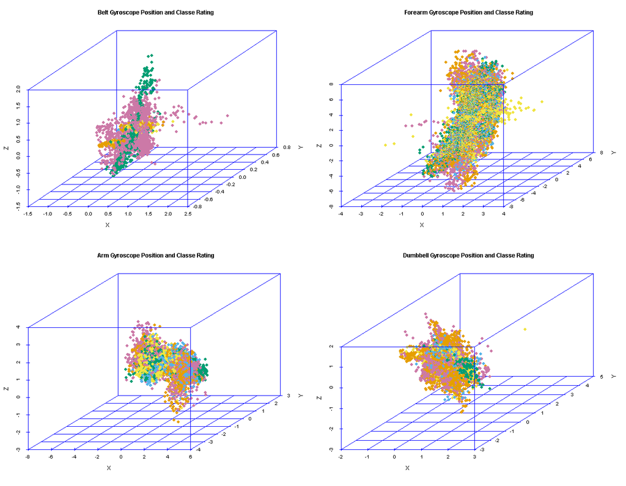

```r
  par(mfrow=c(2,2))
  cols <- c('classe', 'pColour', 'gyros_belt_x', 'gyros_belt_y', 'gyros_belt_z')
  g.gyro.belt <- with(training[, cols], scatterplot3d(x=gyros_belt_x, y=gyros_belt_y, z=gyros_belt_z, color=pColour, col.axis = 'blue', col.grid = 'blue', pch=19, main="Belt Gyroscope Position and Classe Rating", xlab='X', ylab='Y',zlab='Z', cex.symbols = 1.25))

  cols <- c('classe', 'pColour', 'gyros_forearm_x', 'gyros_forearm_y', 'gyros_forearm_y')
  g.gyro.forearm <- with(training[, cols], scatterplot3d(x=gyros_forearm_x, y=gyros_forearm_y, z=gyros_forearm_y, color=pColour, col.axis = 'blue', col.grid = 'blue', pch=19, main="Forearm Gyroscope Position and Classe Rating", xlab='X', ylab='Y',zlab='Z', cex.symbols = 1.25))

  cols <- c('classe', 'pColour', 'gyros_arm_x', 'gyros_arm_y', 'gyros_arm_z')
  g.gyro.arm <- with(training[, cols], scatterplot3d(x=gyros_arm_x, y=gyros_arm_y, z=gyros_arm_z, color=pColour, col.axis = 'blue', col.grid = 'blue', pch=19, main='Arm Gyroscope Position and Classe Rating', xlab='X', ylab='Y',zlab='Z', cex.symbols = 1.25))

  cols <- c('classe', 'pColour', 'gyros_dumbbell_x', 'gyros_dumbbell_y', 'gyros_dumbbell_z')
  g.gyro.dumbbell <- with(training[, cols], scatterplot3d(x=gyros_dumbbell_x, y=gyros_dumbbell_y, z=gyros_dumbbell_z, color=pColour, col.axis = 'blue', col.grid = 'blue', pch=19, main="Dumbbell Gyroscope Position and Classe Rating", xlab='X', ylab='Y',zlab='Z', cex.symbols = 1.25))
```

#### Magnet Position

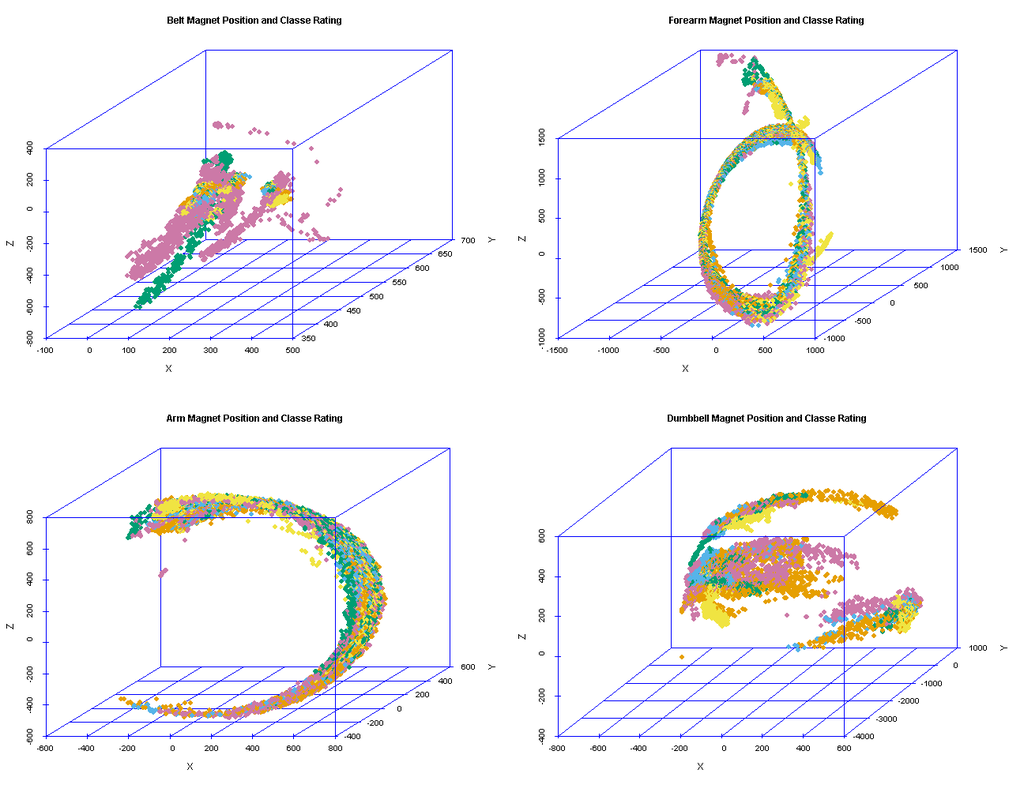

```r
  par(mfrow=c(2,2))
cols <- c('classe', 'pColour', 'magnet_belt_x', 'magnet_belt_y', 'magnet_belt_z')
  g.magnet.belt <- with(training[, cols], scatterplot3d(x=magnet_belt_x, y=magnet_belt_y, z=magnet_belt_z, color=pColour, col.axis = 'blue', col.grid = 'blue', pch=19, main="Belt Magnet Position and Classe Rating", xlab='X', ylab='Y',zlab='Z', cex.symbols = 1.25))

  cols <- c('classe', 'pColour', 'magnet_forearm_x', 'magnet_forearm_y', 'magnet_forearm_y')
  g.magneto.forearm <- with(training[, cols], scatterplot3d(x=magnet_forearm_x, y=magnet_forearm_y, z=magnet_forearm_y, color=pColour, col.axis = 'blue', col.grid = 'blue', pch=19, main="Forearm Magnet Position and Classe Rating", xlab='X', ylab='Y',zlab='Z', cex.symbols = 1.25))

  cols <- c('classe', 'pColour', 'magnet_arm_x', 'magnet_arm_y', 'magnet_arm_z')
  g.magnet.arm <- with(training[, cols], scatterplot3d(x=magnet_arm_x, y=magnet_arm_y, z=magnet_arm_z, color=pColour, col.axis = 'blue', col.grid = 'blue', pch=19, main='Arm Magnet Position and Classe Rating', xlab='X', ylab='Y',zlab='Z', cex.symbols = 1.25))

  cols <- c('classe', 'pColour', 'magnet_dumbbell_x', 'magnet_dumbbell_y', 'magnet_dumbbell_z')
  g.magnet.dumbbell <- with(training[, cols], scatterplot3d(x=magnet_dumbbell_x, y=magnet_dumbbell_y, z=magnet_dumbbell_z, color=pColour, col.axis = 'blue', col.grid = 'blue', pch=19, main="Dumbbell Magnet Position and Classe Rating", xlab='X', ylab='Y',zlab='Z', cex.symbols = 1.25))
```

### Outliers

The 3D scatterplots of the Training data suggest outliers existing in some variables which will be removed in order to reduce the skew in the distribution and prevent distortion in later analysis of Principle Components.

#### Threshold Function

The function calculates a lower and upper threshold above and below the inter quantile range. The distance of the threshold is set by the parameter *m*. For the purposes of this analysis *m* will be set at 5 which is very conservative, the reason being I do not understand the domain and only wish to remove what would seem very extreme values in each range of variables.

```r
    OutlierThresholds <- function(data, multiplier) {
          m <- multiplier; q <- quantile(data); lowerq <- q[2]; upperq <- q[4]; iqr <- upperq - lowerq
          lowerthreshhold <- as.numeric(lowerq - (iqr * m)); upperthreshold <- as.numeric((iqr * m) + upperq)
          c('lowerthreshhold'=lowerthreshhold, 'upperthreshold'=upperthreshold)}
```

#### Calculate Outlier Thresholds

Iterate through the variable columns in the Training set and calculate lower and upper cut-off points outside which range outliers would deem to exist:

```r
  exclude <- c(1,2,3,4,5,6,55,56); m <- 5; colnames <- names(training)
  thresholds <- data.frame(VariableName=character(), Lower=numeric(), Upper=numeric(), stringsAsFactors=FALSE)
  for (i in 1:ncol(training)) {
    if(!i %in% exclude) {
      t <- OutlierThresholds(as.numeric(training[,i]), m)
      rname <- as.character(i)
      thresholds[rname,]$VariableName <- colnames[i]; thresholds[rname,]$Lower <- t[1]; thresholds[rname,]$Upper <- t[2]
    }
  }
  colrows <- as.integer(nrow(thresholds) / 3)
  start1<-1; end1<-colrows; start2<-end1+1; end2<-end1+colrows; start3<-end2+1; end3<-nrow(thresholds)
```

```
##     VariableName     Lower    Upper
## 7      roll_belt  -608.400 732.5000
## 8     pitch_belt   -61.540  77.9125
## 9       yaw_belt  -586.300 509.3000
## 10  gyros_belt_x    -0.730   0.8100
## 11  gyros_belt_y    -0.550   0.6600
## 12  gyros_belt_z    -1.100   0.8800
## 13  accel_belt_x  -101.000  75.0000
## 14  accel_belt_y  -287.000 351.0000
## 15  accel_belt_z -1107.000 972.0000
## 16 magnet_belt_x  -241.000 309.0000
## 17 magnet_belt_y   436.000 755.0000
## 18 magnet_belt_z  -720.000  39.0000
## 19      roll_arm  -579.025 624.6500
## 20     pitch_arm  -211.800 197.4000
## 21       yaw_arm  -490.200 494.3000
## 22   gyros_arm_x   -15.960  16.1600
```

```
##        VariableName      Lower     Upper
## 23      gyros_arm_y    -5.5400    4.9100
## 24      gyros_arm_z    -4.0800    4.7200
## 25      accel_arm_x -1872.0000 1714.0000
## 26      accel_arm_y -1024.0000 1110.0000
## 27      accel_arm_z  -981.0000  856.0000
## 28     magnet_arm_x -5007.0000 5344.0000
## 29     magnet_arm_y -1706.5000 2014.2500
## 30     magnet_arm_z -2011.5000 2677.2500
## 31    roll_dumbbell  -458.1550  506.3659
## 32   pitch_dumbbell  -332.0937  308.7262
## 33     yaw_dumbbell  -859.8829  861.2744
## 34 gyros_dumbbell_x    -1.9300    2.2500
## 35 gyros_dumbbell_y    -1.8900    1.9600
## 36 gyros_dumbbell_z    -2.0100    1.7300
## 37 accel_dumbbell_x  -350.0000  310.0000
## 38 accel_dumbbell_y  -599.0000  699.0000
```

```
##         VariableName     Lower     Upper
## 39  accel_dumbbell_z -1036.000  933.0000
## 40 magnet_dumbbell_x -1665.000  821.0000
## 41 magnet_dumbbell_y  -548.000 1168.0000
## 42 magnet_dumbbell_z  -750.000  801.0000
## 43      roll_forearm  -706.785  847.4875
## 44     pitch_forearm  -141.000  169.2000
## 45       yaw_forearm  -958.600 1000.5000
## 46   gyros_forearm_x    -4.070    4.4000
## 47   gyros_forearm_y   -17.010   17.2000
## 48   gyros_forearm_z    -3.530    3.8400
## 49   accel_forearm_x -1451.000 1354.0000
## 50   accel_forearm_y -1200.000 1572.0000
## 51   accel_forearm_z -1227.000 1072.0000
## 52  magnet_forearm_x -3314.500 2628.2500
## 53  magnet_forearm_y -3649.000 4392.0000
## 54  magnet_forearm_z -2168.000 3002.0000
```

Identify all rows containing variables whose value lies outside the ranges in dataframe *thresholds*:

```r
  # Check each variable values outside the below\above the threshold
  all.outliers <- data.frame(X=numeric(), VariableName=character(), Value=numeric(), Lower=numeric(), Upper=numeric(), stringsAsFactors=FALSE)

  for (i in 1:ncol(training)) {
    if(!i %in% exclude) {
      varname <- colnames[i]
      lower <- thresholds[thresholds$VariableName==varname,]$Lower; upper <- thresholds[thresholds$VariableName==varname,]$Upper
      outliers <- training[which( training[,i]<lower | training[,i]>upper), c(1, i)]
      if (nrow(outliers) > 0){
        all.outliers <- rbind( all.outliers,
                               data.frame(X=outliers[,1], VariableName=rep(varname, nrow(outliers)), Value=outliers[,2], Lower=rep(lower, nrow(outliers)), Upper=rep(upper, nrow(outliers))))
      }}}
```

#### Outliers Summary:

```r
  data.frame(table(all.outliers$VariableName))
```

```
##                 Var1 Freq
## 1       gyros_belt_x   50
## 2       gyros_belt_y    1
## 3       gyros_belt_z   75
## 4       accel_belt_x   10
## 5      magnet_belt_x   33
## 6      magnet_belt_y   89
## 7      magnet_belt_z   20
## 8   gyros_dumbbell_x    1
## 9   gyros_dumbbell_y   41
## 10  gyros_dumbbell_z    3
## 11 magnet_dumbbell_y  700
## 12   gyros_forearm_z    5
```

#### Remove Outliers:

```r
  writeLines('Training set dimensions before removal of outliers:')
```

```
## Training set dimensions before removal of outliers:
```

```r
  dim(training);
```

```
## [1] 11532    56
```

```r
  training <- training[-all.outliers$X,];
  writeLines('Training set dimensions after:')
```

```
## Training set dimensions after:
```

```r
  dim(training)
```

```
## [1] 11161    56
```

### Proportion of Each Outcome in Training Dataset

It’s useful to see how the actual classe values are distributed in the Training as a quick way to be able to check our later predictions look sensible (assuming original data was normally distributed):

```r
  round(prop.table(table(training[,'classe'])), 2)
```

```
##
##    A    B    C    D    E
## 0.28 0.20 0.17 0.16 0.19
```

### Variable Correlation

Analysing correlated variables is useful in understanding the Training data and informs the feature selection decision, therefore helping reduce potential for over-fitting the prediction models:

```r
  exclude <- c(1,2,3,4,5,6,55,56)
  cm <- cor(training[,-exclude])
  # Set correlations on or below off diagonal to 0 so ommitted from output
  diag(cm) <- 0; cm[lower.tri(cm)] <- 0
  df.cm <- as.data.frame(as.table(cm))
  # Omit the inversely correlated pairing
  df.cm <- df.cm[!df.cm$Var1==df.cm$Var2,]
  df.cm$FreqAbs = abs(df.cm$Freq)
  df.cm.top <- head(df.cm[order(df.cm$FreqAbs, decreasing = TRUE),], 30)
  colrows <- as.integer(nrow(df.cm.top) / 3)
  start1<-1; end1<-colrows; start2<-end1+1; end2<-end1+colrows; start3<-end2+1; end3<-nrow(df.cm.top)
```

```
##               Var1             Var2       Freq   FreqAbs
## 385      roll_belt     accel_belt_z -0.9919528 0.9919528
## 290     pitch_belt     accel_belt_x -0.9654453 0.9654453
## 392   accel_belt_y     accel_belt_z -0.9369296 0.9369296
## 337      roll_belt     accel_belt_y  0.9287338 0.9287338
## 784    gyros_arm_x      gyros_arm_y -0.9190959 0.9190959
## 439   accel_belt_x    magnet_belt_x  0.9031307 0.9031307
## 434     pitch_belt    magnet_belt_x -0.9006527 0.9006527
## 1563  yaw_dumbbell accel_dumbbell_z  0.8495669 0.8495669
## 1027   accel_arm_x     magnet_arm_x  0.8215986 0.8215986
## 539  magnet_belt_y    magnet_belt_z  0.8198316 0.8198316
```

```
##                 Var1              Var2       Freq   FreqAbs
## 97         roll_belt          yaw_belt  0.8195195 0.8195195
## 1127    magnet_arm_y      magnet_arm_z  0.8170799 0.8170799
## 1466  pitch_dumbbell  accel_dumbbell_x  0.8080964 0.8080964
## 913        roll_belt       accel_arm_y -0.7962054 0.7962054
## 1078    magnet_arm_x      magnet_arm_y -0.7943859 0.7943859
## 921     accel_belt_z       accel_arm_y  0.7885761 0.7885761
## 1125     accel_arm_z      magnet_arm_z  0.7853009 0.7853009
## 387         yaw_belt      accel_belt_z -0.7813387 0.7813387
## 1636    gyros_belt_x magnet_dumbbell_y  0.7737708 0.7737708
## 2252 accel_forearm_y  magnet_forearm_y  0.7716554 0.7716554
```

```
##                   Var1              Var2       Freq   FreqAbs
## 1666 magnet_dumbbell_x magnet_dumbbell_y -0.7511410 0.7511410
## 435           yaw_belt     magnet_belt_x  0.7485937 0.7485937
## 1588      gyros_belt_x magnet_dumbbell_x -0.7357714 0.7357714
## 2009   gyros_forearm_y   gyros_forearm_z  0.7312884 0.7312884
## 920       accel_belt_y       accel_arm_y -0.7283536 0.7283536
## 1513     roll_dumbbell  accel_dumbbell_y  0.7213139 0.7213139
## 291           yaw_belt      accel_belt_x  0.7186530 0.7186530
## 1075       accel_arm_x      magnet_arm_y -0.7174342 0.7174342
## 98          pitch_belt          yaw_belt -0.7074625 0.7074625
## 1567  accel_dumbbell_x  accel_dumbbell_z  0.6804503 0.6804503
```

Many of the separate measurements types taken at each sensor are highly correlated e.g. roll, pitch & yaw measurements on the belt highly correlate with accelerator x, z & y positions of the belt. This suggests certain measurements can be ommitted without compromising prediction accuracy. This also helps prevent over-fitting the models too closely to the Training set.

### Principle Component Analysis

```r
  exclude <- c(1,2,3,4,5,6,55,56); pc <- prcomp(training[,-exclude], scale. = TRUE); summary(pc)
```

```
## Importance of components:
##                           PC1    PC2     PC3     PC4     PC5     PC6     PC7    PC8     PC9    PC10    PC11    PC12    PC13    PC14    PC15    PC16    PC17    PC18    PC19    PC20
## Standard deviation     2.7962 2.6943 2.14633 1.91847 1.73051 1.50804 1.44072 1.3664 1.28566 1.27383 1.13155 1.09908 0.99549 0.89951 0.88927 0.85614 0.84488 0.80141 0.73994 0.67411
## Proportion of Variance 0.1629 0.1512 0.09597 0.07668 0.06239 0.04738 0.04324 0.0389 0.03444 0.03381 0.02667 0.02517 0.02065 0.01686 0.01647 0.01527 0.01487 0.01338 0.01141 0.00947
## Cumulative Proportion  0.1629 0.3141 0.41010 0.48678 0.54917 0.59655 0.63979 0.6787 0.71312 0.74693 0.77360 0.79877 0.81941 0.83627 0.85275 0.86802 0.88289 0.89627 0.90767 0.91714
##                           PC21    PC22    PC23    PC24   PC25    PC26    PC27    PC28   PC29    PC30    PC31    PC32    PC33    PC34    PC35    PC36    PC37    PC38    PC39
## Standard deviation     0.67007 0.61880 0.59536 0.58533 0.5542 0.52569 0.50113 0.47541 0.4545 0.38527 0.38059 0.35879 0.34785 0.31703 0.28798 0.27057 0.25828 0.23584 0.22625
## Proportion of Variance 0.00935 0.00798 0.00738 0.00714 0.0064 0.00576 0.00523 0.00471 0.0043 0.00309 0.00302 0.00268 0.00252 0.00209 0.00173 0.00153 0.00139 0.00116 0.00107
## Cumulative Proportion  0.92650 0.93447 0.94186 0.94899 0.9554 0.96115 0.96638 0.97109 0.9754 0.97849 0.98151 0.98419 0.98671 0.98880 0.99053 0.99205 0.99344 0.99460 0.99567
##                           PC40    PC41    PC42    PC43   PC44    PC45    PC46    PC47    PC48
## Standard deviation     0.19930 0.18466 0.18223 0.16255 0.1553 0.15063 0.13504 0.08336 0.04885
## Proportion of Variance 0.00083 0.00071 0.00069 0.00055 0.0005 0.00047 0.00038 0.00014 0.00005
## Cumulative Proportion  0.99650 0.99721 0.99790 0.99845 0.9990 0.99943 0.99981 0.99995 1.00000
```

The first 35 Principle Components explain > 99% of the variance in the Training dataset.

## Train Models and Run Predictions Against Validation Dataset

The Machine Learning problem requires us to predict the outcome of a factor variable so we will use models support Classification type prediction:

```r
  getModelInfo()$lda$type
```

```
## [1] "Classification"
```

```r
  getModelInfo()$rf$type
```

```
## [1] "Classification" "Regression"
```

```r
  getModelInfo()$gbm$type
```

```
## [1] "Regression"     "Classification"
```

### Configure Training Control for Cross Validation

The number of tuning parameters (i.e. number of variables) used from the Training dataset will vary. This needs to be considered when setting the number of seed values used.

The data is pre-processed to be Scaled and Centred, i.e. normalised, as another parameter of the Training Control. This reduces the level of skew that may be present in the distribution if not standard.

We will only going to consider the first 35 Principle Components of the Training set; this explains >99% of the variance in the data, therefore we have 35 Tuning Parameters.

```r
  set.seed(666)
  nParams <- 35 # First 35 Principle Components
  seeds <- vector(mode = "list", length = 11)
  for(i in 1:10) seeds[[i]]<- sample.int(n=1000, nParams)
  seeds[[11]]<-sample.int(1000, 1)
  tc <- trainControl(method='cv', number=10, allowParallel=TRUE, preProcOptions = c('scale','center'), seeds=seeds)
```

Create a data frame to store prediction results from each model. These will be used later for comparison:

```r
  df.combined.predictions <- data.frame()
```

Training the Random Forest and Boosted Trees models has proved too slow when using the entire Training Set so mutiple cores are configured to reduce overall time by calculating in parallel:

```r
  cl <- makeCluster(2); registerDoParallel(cl)
```

### Models Using Principle Components

Create a dataframe containing the *classe* value in the Training set and first 35 Princple Components (explaining 99% of variance):

```r
  training.pca <- data.frame(classe = training$classe, pc$x); training.pca <- training.pca[,1:36]
```

#### Linear Discriminant Analysis(LDA) Model

Train the LDA model on the Principal Components of the Training set. Predict *classe* on the Validation set and add the predictions to the summary dataframe:

```r
  validation.pca <- predict(pc, newdata=validation)
  validation.pca <- as.data.frame(validation.pca)
  validation.pca <- validation.pca[,1:36]
```

```r
  lda.pca.varfit.cv <- train(classe ~ ., data=training.pca, method='lda', prox=TRUE, trControl=tc)
  # Predict
  lda.pca.prediction.cv <- as.data.frame(predict(lda.pca.varfit.cv, validation.pca))
  names(lda.pca.prediction.cv) <- 'lda.pca.prediction.cv'
  # Add to combined data frame
  df.combined.predictions <- data.frame(lda.pca.prediction.cv)
```

### Sub-sample of Training Set for Random Forest and Boosted Tree Models

Training the Random Forest and Boosted Tree models using the full training could not be completed so a sub- sample (approximately 15%) of the Training set is used for these models. However the same sub-sample of training data is always used for comparibility.

```r
  samplerows <- sample(c(1:nrow(training)), size=as.integer(nrow(training)* 0.15))
  small.training <- training[samplerows, ]
```

```r
  small.pca <- prcomp(small.training[,-exclude], scale. = TRUE)
  summary(small.pca)
```

```
## Importance of components:
##                           PC1    PC2     PC3     PC4     PC5     PC6     PC7     PC8     PC9    PC10    PC11    PC12    PC13    PC14    PC15    PC16    PC17    PC18    PC19
## Standard deviation     2.8191 2.6647 2.16092 1.91484 1.73431 1.48958 1.45346 1.40442 1.30929 1.25600 1.11412 1.09745 1.01612 0.91017 0.88560 0.84373 0.83750 0.79700 0.76163
## Proportion of Variance 0.1656 0.1479 0.09728 0.07639 0.06266 0.04623 0.04401 0.04109 0.03571 0.03287 0.02586 0.02509 0.02151 0.01726 0.01634 0.01483 0.01461 0.01323 0.01209
## Cumulative Proportion  0.1656 0.3135 0.41078 0.48717 0.54983 0.59606 0.64007 0.68116 0.71687 0.74974 0.77560 0.80069 0.82220 0.83946 0.85580 0.87063 0.88524 0.89847 0.91056
##                           PC20    PC21    PC22    PC23    PC24    PC25    PC26    PC27    PC28    PC29    PC30    PC31    PC32    PC33    PC34   PC35    PC36    PC37    PC38
## Standard deviation     0.66792 0.65637 0.61299 0.58811 0.57489 0.54598 0.52679 0.49715 0.47928 0.45162 0.36394 0.34894 0.34281 0.32175 0.30815 0.2943 0.26764 0.25371 0.23178
## Proportion of Variance 0.00929 0.00898 0.00783 0.00721 0.00689 0.00621 0.00578 0.00515 0.00479 0.00425 0.00276 0.00254 0.00245 0.00216 0.00198 0.0018 0.00149 0.00134 0.00112
## Cumulative Proportion  0.91985 0.92883 0.93666 0.94386 0.95075 0.95696 0.96274 0.96789 0.97267 0.97692 0.97968 0.98222 0.98467 0.98683 0.98880 0.9906 0.99210 0.99344 0.99456
##                           PC39   PC40    PC41    PC42    PC43    PC44    PC45    PC46    PC47    PC48
## Standard deviation     0.22375 0.2186 0.19044 0.17727 0.15824 0.14974 0.14631 0.13422 0.08076 0.04629
## Proportion of Variance 0.00104 0.0010 0.00076 0.00065 0.00052 0.00047 0.00045 0.00038 0.00014 0.00004
## Cumulative Proportion  0.99560 0.9966 0.99735 0.99801 0.99853 0.99900 0.99944 0.99982 0.99996 1.00000
```

Note, at the 35th PCA component >99% of the variance in the smaller sub-sample of the Training set is still captured:

```r
  small.training.pca <- data.frame(classe=small.training$classe, small.pca$x); small.training.pca <- small.training.pca[,1:36]
```

Again, create a dataframe containing the *classe* value in the Training set and only first 35 Princple Components. As before, transform the validation data into Principle Components although this time based upon the PCA result object from the sub-sample training data:

```r
  validation.pca.small <- predict(small.pca, newdata=validation)
  validation.pca.small <- as.data.frame(validation.pca.small)
  validation.pca.small <- validation.pca.small[,1:36]
```

#### Random Forest Model on Principle Components

```r
  rf.pca.varfit <- train(classe ~ ., data=small.training.pca, method='rf', prox=FALSE, trainControl=tc)
  # Predict
  rf.pca.prediction <- as.data.frame(predict(rf.pca.varfit, validation.pca.small))
  # Add to combined data frame
  df.combined.predictions <- data.frame(df.combined.predictions,'rf.pca.prediction'= rf.pca.prediction[,1])
```

#### Boosted Tree Model on Principle Components

Training the Boosted Tree model on the Principle Components had to be called directly as it would not calculate correctly via the caret package when using the Training Control to pass the seeds:

```r
  set.seed(666)
  bt.pca.varfit <-  gbm(classe ~ ., data=small.training.pca, cv.folds=10, distribution='multinomial')
  # Predict
  bt.pca.prediction <- as.data.frame(predict(bt.pca.varfit, validation.pca))
```

```
## Using 100 trees...
```

```r
  names(bt.pca.prediction) <- c('A','B','C','D','E')
  bt.pca.prediction <- as.data.frame(colnames(bt.pca.prediction)[max.col(bt.pca.prediction,ties.method='first')])
  # Add to combined data frame
  df.combined.predictions <- data.frame(df.combined.predictions, 'bt.pca.prediction'= bt.pca.prediction[,1])
```

### Prediction Models Using Training Data Variables Directly

The same models (LDA, Random Forest and Boosted Tree) will now be used to predict outcomes on the Validation data using each of the four ‘types’ of measurement available in the Training data, namely:

1. Roll, Pitch & Yaw of the sensors.
2. Gyroscope Position (X, Y & Z axis measurement)
3. Accelerometer Position (X, Y & Z axis measurement)
4. Magnet Position (X, Y & Z axis measurement)

The main reason for experimenting on each of these ‘types’ of measurement separately is the high levels of correlation that exist between these types as shown in the earlier *Variable Correlation* section above.

Firstly define which variable names belong to each measurement type:

```r
  v.rpy.arm = c("roll_arm","pitch_arm","yaw_arm")
  v.rpy.forearm = c("roll_forearm","pitch_forearm","yaw_forearm")
  v.rpy.belt = c("roll_belt","pitch_belt","yaw_belt")
  v.rpy.dumbbell = c("roll_dumbbell","pitch_dumbbell","yaw_dumbbell")
  v.rpy.all <- c(v.rpy.arm, v.rpy.forearm, v.rpy.belt, v.rpy.dumbbell)

  v.gyro.arm = c("gyros_arm_x","gyros_arm_y","gyros_arm_z")
  v.gyro.forearm = c("gyros_forearm_x","gyros_forearm_y","gyros_forearm_z")
  v.gyro.belt = c("gyros_belt_x","gyros_belt_y","gyros_belt_z")
  v.gyro.dumbbell = c("gyros_dumbbell_x","gyros_dumbbell_y","gyros_dumbbell_z")
  v.gyro.all = c(v.gyro.arm, v.gyro.forearm, v.gyro.belt, v.gyro.dumbbell)

  v.accel.arm = c("accel_arm_x","accel_arm_y","accel_arm_z")
  v.accel.forearm = c("accel_forearm_x","accel_forearm_y","accel_forearm_z")
  v.accel.belt = c("accel_belt_x","accel_belt_y","accel_belt_z")
  v.accel.dumbbell = c("accel_dumbbell_x","accel_dumbbell_y","accel_dumbbell_z")
  v.accel.all <- c(v.accel.arm, v.accel.forearm, v.accel.belt, v.accel.dumbbell)

  v.magnet.arm = c("magnet_arm_x","magnet_arm_y","magnet_arm_z")
  v.magnet.forearm = c("magnet_forearm_x","magnet_forearm_y","magnet_forearm_z")
  v.magnet.belt = c("magnet_belt_x","magnet_belt_y","magnet_belt_z")
  v.magnet.dumbbell = c("magnet_dumbbell_x","magnet_dumbbell_y","magnet_dumbbell_z")
  v.magnet.all <- c(v.magnet.arm, v.magnet.forearm, v.magnet.belt, v.magnet.dumbbell)
```

### Re-Configure the Training Control for Cross Validation

The number of tuning parameters now used from the Training dataset is now 12.

```r
  set.seed(666)
  nParams <- 12 # e.g. length(v.rpy.all)
  seeds <- vector(mode = "list", length = 11)
  for(i in 1:10) seeds[[i]]<- sample.int(n=1000, nParams)
  seeds[[11]]<-sample.int(1000, 1)
  tc <- trainControl(method='cv', number=10, allowParallel=TRUE, preProcOptions = c('scale','center'), seeds=seeds)
```

#### Roll, Pitch & Yaw LDA Model

```r
  lda.varfit.v.rpy.all <- train(classe ~ ., data=training[, c('classe',v.rpy.all)], method='lda', trControl=tc)
  # Predict
  lda.v.rpy.all.prediction.cv <- as.data.frame(predict(lda.varfit.v.rpy.all, newdata=validation))
  # Add to combined data frame
  df.combined.predictions <- data.frame(df.combined.predictions, 'lda.v.rpy.all.prediction.cv' = lda.v.rpy.all.prediction.cv[,1])
```

#### Gyro LDA Model

```r
  lda.varfit.v.gyro.all <- train(classe ~ ., data=training[, c('classe',v.gyro.all)], method='lda',trControl=tc)
  # Predict
  lda.v.gyro.all.prediction.cv <- as.data.frame(predict(lda.varfit.v.gyro.all, newdata=validation))
  # Add to combined data frame
  df.combined.predictions <- data.frame(df.combined.predictions,'lda.v.gyro.all.prediction.cv'=lda.v.gyro.all.prediction.cv[,1])
```

#### Accelerator LDA Model

```r
  lda.varfit.v.accel.all <- train(classe ~ .,data=training[, c('classe',v.accel.all)],method='lda',trControl=tc)
  # Predict
  lda.v.accel.all.prediction.cv <- as.data.frame(predict(lda.varfit.v.accel.all, newdata=validation))
  # Add to combined data frame
  df.combined.predictions <- data.frame(df.combined.predictions,'lda.v.accel.all.prediction.cv'=lda.v.accel.all.prediction.cv[,1])
```

#### Magnet LDA Model

```r
  lda.varfit.v.magnet.all <- train(classe ~ .,data=training[, c('classe',v.magnet.all)],method='lda',trControl=tc)
  # Predict
  lda.v.magnet.all.prediction.cv <- as.data.frame(predict(lda.varfit.v.magnet.all, newdata=validation))
  # Add to combined data frame
  df.combined.predictions <- data.frame(df.combined.predictions,'lda.v.magnet.all.prediction.cv'=lda.v.magnet.all.prediction.cv[,1])
```

#### Roll, Pitch & Yaw Random Forest Model

```r
  rf.v.rpy.all.varfit <- train(classe ~ .,data=small.training[,c('classe',v.rpy.all)],method='rf',prox=FALSE,trainControl=tc)
  # Predict
  rf.v.rpy.all.prediction.cv <- as.data.frame(predict(rf.v.rpy.all.varfit, newdata=validation))
  # Add to combined data frame
  df.combined.predictions <- data.frame(df.combined.predictions,'rf.v.rpy.all.prediction.cv'=rf.v.rpy.all.prediction.cv[,1])
```

#### Gyro Random Forest Model

```r
  rf.v.gyro.all.varfit <- train(classe ~ .,data=small.training[, c('classe', v.gyro.all)], method='rf', prox=FALSE,trainControl=tc)
  # Predict
  rf.v.gyro.all.prediction.cv <- as.data.frame(predict(rf.v.gyro.all.varfit, newdata=validation))
  # Add to combined data frame
  df.combined.predictions <- data.frame(df.combined.predictions,'rf.v.gyro.all.prediction.cv'=rf.v.gyro.all.prediction.cv[,1])
```

#### Accelerator Random Forest Model

```r
  rf.v.accel.all.varfit <- train(classe ~ .,data=small.training[, c('classe', v.accel.all)],method='rf', prox=FALSE,trainControl=tc)
  # Predict
  rf.v.accel.all.prediction.cv <- as.data.frame(predict(rf.v.accel.all.varfit, newdata=validation))
  # Add to combined data frame
  df.combined.predictions <- data.frame(df.combined.predictions,'rf.v.accel.all.prediction.cv'=rf.v.accel.all.prediction.cv[,1])
```

#### Magnet Random Forest Model

```r
 rf.v.magnet.all.varfit <- train(classe ~ .,data=small.training[,c('classe',v.magnet.all)],method='rf',prox=FALSE,trainControl=tc)
  # Predict
  rf.v.magnet.all.prediction.cv <- as.data.frame(predict(rf.v.magnet.all.varfit, newdata=validation))
  # Add to combined data frame
  df.combined.predictions <- data.frame(df.combined.predictions,'rf.v.magnet.all.prediction.cv'=rf.v.magnet.all.prediction.cv[,1])
```

#### RPY Boosted Tree

```r
  set.seed(666)
  bt.v.rpy.all.varfit <-  gbm(classe ~ ., data=small.training[,c('classe',v.rpy.all)], cv.folds=10,  distribution='multinomial',interaction.depth = 3,n.trees = 150,shrinkage = 0.1,n.minobsinnode = 10)
  # Predict
  bt.v.rpy.all.prediction.cv <- as.data.frame(predict(bt.v.rpy.all.varfit, newdata=validation))
```

```
## Using 150 trees...
```

```r
  names(bt.v.rpy.all.prediction.cv) <- c('A','B','C','D','E')
  bt.v.rpy.all.prediction.cv <- as.data.frame(colnames(bt.v.rpy.all.prediction.cv)[max.col(bt.v.rpy.all.prediction.cv, ties.method='first')])
  # Add to combined data frame
  df.combined.predictions <- data.frame(df.combined.predictions,'bt.v.rpy.all.prediction.cv'=bt.v.rpy.all.prediction.cv[,1])
```

#### Gyro Boosted Tree

```r
  set.seed(666)
  bt.v.gyro.all.varfit <-  gbm(classe ~ ., data=small.training[,c('classe',v.gyro.all)], cv.folds=10, distribution='multinomial',interaction.depth = 3,n.trees = 150,shrinkage = 0.1,n.minobsinnode = 10)
  # Predict
  bt.v.gyro.all.prediction.cv <- as.data.frame(predict(bt.v.gyro.all.varfit, newdata=validation))
```

```
## Using 145 trees...
```

```r
  names(bt.v.gyro.all.prediction.cv) <- c('A','B','C','D','E')
  bt.v.gyro.all.prediction.cv <- as.data.frame(colnames(bt.v.gyro.all.prediction.cv)[max.col(bt.v.gyro.all.prediction.cv, ties.method='first')])
  # Add to combined data frame
  df.combined.predictions <- data.frame(df.combined.predictions,'bt.v.gyro.all.prediction.cv'=bt.v.gyro.all.prediction.cv[,1])
```

#### Accelerator Boosted Tree

```r
  set.seed(666)
  bt.v.accel.all.varfit <-  gbm(classe ~ ., data=small.training[,c('classe',v.accel.all)], cv.folds=10, distribution='multinomial',interaction.depth = 3,n.trees = 150,shrinkage = 0.1,n.minobsinnode = 10)
  # Predict
  bt.v.accel.all.prediction.cv <- as.data.frame(predict(bt.v.accel.all.varfit, newdata=validation))
```

```
## Using 150 trees...
```

```r
  names(bt.v.accel.all.prediction.cv) <- c('A','B','C','D','E')
  bt.v.accel.all.prediction.cv <- as.data.frame(colnames(bt.v.accel.all.prediction.cv)[max.col(bt.v.accel.all.prediction.cv, ties.method='first')])
  # Add to combined data frame
  df.combined.predictions <- data.frame(df.combined.predictions,'bt.v.accel.all.prediction.cv'=bt.v.accel.all.prediction.cv[,1])
```

#### Magnet Boosted Tree

```r
  set.seed(666)
  bt.v.magnet.all.varfit <-  gbm(classe ~ ., data=small.training[,c('classe', v.magnet.all)], cv.folds=10, distribution='multinomial',interaction.depth = 3,n.trees = 150,shrinkage = 0.1,n.minobsinnode = 10)
  # Predict
  bt.v.magnet.all.prediction.cv <- as.data.frame(predict(bt.v.magnet.all.varfit, newdata=validation))
```

```
## Using 150 trees...
```

```r
names(bt.v.magnet.all.prediction.cv) <- c('A','B','C','D','E')
  bt.v.magnet.all.prediction.cv <- as.data.frame(colnames(bt.v.magnet.all.prediction.cv)[max.col(bt.v.magnet.all.prediction.cv, ties.method='first')])
  # Add to combined data frame
  df.combined.predictions <- data.frame(df.combined.predictions,'bt.v.magnet.all.prediction.cv'=bt.v.magnet.all.prediction.cv[,1])
```

### Prediction Results

```r
  df.combined.predictions <- data.frame(df.combined.predictions, 'classe'=validation$classe)
  df.results <- data.frame(stringsAsFactors = FALSE)
  for (i in 1 : (ncol(df.combined.predictions) - 1)) {
        col_name <- paste0(names(df.combined.predictions)[i],'.match')
        # Compare current column of predictions against actual classe value
        df.compare <- df.combined.predictions[,i] == df.combined.predictions[,ncol(df.combined.predictions)]
        # Add new column of comparisons
        if (nrow(df.results) == 0){df.results <- as.data.frame(df.compare)} else
                                  {df.results <- as.data.frame(cbind(df.results,as.data.frame(df.compare)))}
        names(df.results)[i] = col_name}
  df.accuracy <- data.frame(Prediction=character(), Accuracy=numeric(), stringsAsFactors=FALSE)
  for (i in 1 : (ncol(df.results))) {
          col_name <- str_replace(names(df.results)[i],'.match','.accuracy')
          # Calculate accuracy of prediction against actual classe
          accuracy <- sum((df.results[,i]==TRUE) * 1) / nrow(df.results)
          df.accuracy[i,]$Prediction <- col_name; df.accuracy[i,]$Accuracy <- round(accuracy, 3)
          rownames(df.accuracy)[i] <- col_name}
  # Order by descending Accuracy
  df.accuracy <- df.accuracy[order(df.accuracy$Accuracy, decreasing=TRUE), 1:2]
  colrows <- as.integer(ceiling(nrow(df.accuracy) / 3))
  start1<-1; end1<-colrows; start2<-end1+1; end2<-end1+colrows; start3<-end2+1; end3<-nrow(df.accuracy)
```

#### Accuracy and Confusion Matrix Results

```
## Prediction:  rf.v.rpy.all.prediction.cv
## Accuracy:  0.919
##
##           Reference
## Prediction    A    B    C    D    E
##          A 1066   42   20   10    3
##          B   15  646   36    5   29
##          C    2   36  596   25   19
##          D    8   12   17  585   18
##          E    3    7    1    4  636
##
## Prediction:  bt.v.rpy.all.prediction.cv
## Accuracy:  0.872
##
##           Reference
## Prediction    A    B    C    D    E
##          A 1012   54   13   12    8
##          B   47  618   54   19   33
##          C   13   47  569   27   28
##          D   18   14   30  553   38
##          E    4   10    4   18  598
##
## Prediction:  rf.pca.prediction
## Accuracy:  0.862
##
##           Reference
## Prediction    A    B    C    D    E
##          A 1021   62   27   17   20
##          B   30  630   49   19   29
##          C    9   37  545   63   25
##          D   27    5   22  503   20
##          E    7    9   27   27  611
##
## Prediction:  rf.v.magnet.all.prediction.cv
## Accuracy:  0.86
##
##           Reference
## Prediction    A    B    C    D    E
##          A 1021   51   34   14   26
##          B   31  609   39   30   56
##          C   10   46  584   53   32
##          D   30   28   12  526   29
##          E    2    9    1    6  562
##
## Prediction:  rf.v.accel.all.prediction.cv
## Accuracy:  0.829
##
##           Reference
## Prediction   A   B   C   D   E
##          A 965  64  60  32  10
##          B  34 589  40  12  76
##          C  31  67 545  52  30
##          D  60  18  11 525  30
##          E   4   5  14   8 559
```

```
## Prediction:  bt.v.magnet.all.prediction.cv
## Accuracy:  0.802
##
##           Reference
## Prediction   A   B   C   D   E
##          A 957  64  36  24  27
##          B  52 557  52  35  42
##          C  17  64 529  65  46
##          D  48  36  43 483  36
##          E  20  22  10  22 554
##
## Prediction:  bt.v.accel.all.prediction.cv
## Accuracy:  0.762
##
##           Reference
## Prediction   A   B   C   D   E
##          A 913  81  82  44  16
##          B  50 524  50  34  91
##          C  41  84 485  45  54
##          D  85  33  31 493  33
##          E   5  21  22  13 511
##
## Prediction:  rf.v.gyro.all.prediction.cv
## Accuracy:  0.689
##
##           Reference
## Prediction   A   B   C   D   E
##          A 880  60 149 133  50
##          B  69 560  90  32 100
##          C  68  50 369  90  16
##          D  56  24  52 324  24
##          E  21  49  10  50 515
##
## Prediction:  lda.pca.prediction.cv
## Accuracy:  0.595
##
##           Reference
## Prediction   A   B   C   D   E
##          A 774 156  63  18  69
##          B 125 368  92  95 112
##          C  74 131 400  68  77
##          D  96  49  80 397 102
##          E  25  39  35  51 345
##
## Prediction:  bt.v.gyro.all.prediction.cv
## Accuracy:  0.582
##
##           Reference
## Prediction   A   B   C   D   E
##          A 735  86 176 165  60
##          B 118 473  89  39  99
##          C 141  84 301 116  22
##          D  89  38  90 256  55
##          E  11  62  14  53 469
```

```
## Prediction:  lda.v.magnet.all.prediction.cv
## Accuracy:  0.52
##
##           Reference
## Prediction   A   B   C   D   E
##          A 774 165 201  72  63
##          B 101 386  92 140 128
##          C  41  74 230  69  95
##          D 131  79 113 289 102
##          E  47  39  34  59 317
##
## Prediction:  lda.v.accel.all.prediction.cv
## Accuracy:  0.515
##
##           Reference
## Prediction   A   B   C   D   E
##          A 756 168 361  92 123
##          B  86 398  82  61 158
##          C  44  85 131  38  27
##          D 185  67  85 377  80
##          E  23  25  11  61 317
##
## Prediction:  lda.v.rpy.all.prediction.cv
## Accuracy:  0.443
##
##           Reference
## Prediction   A   B   C   D   E
##          A 723 180 190  54 119
##          B 117 237  66 128 184
##          C  55 101 275  45 135
##          D 112 122  63 310 112
##          E  87 103  76  92 155
##
## Prediction:  bt.pca.prediction
## Accuracy:  0.429
##
##           Reference
## Prediction   A   B   C   D   E
##          A 841 355 362 203 288
##          B  38 191  25 138  83
##          C  31  28 156  16  55
##          D 175 122  96 231  51
##          E   9  47  31  41 228
##
## Prediction:  lda.v.gyro.all.prediction.cv
## Accuracy:  0.32
##
##           Reference
## Prediction   A   B   C   D   E
##          A 991 557 569 519 484
##          B  61  92  62  49  76
##          C   1   1   4   0  12
##          D  25  18  17  32  24
##          E  16  75  18  29 109
```

LDA model perfomance is a lot poorer, only being 9th most accuarate at 60% using Principle Components.

### Predicting on Combination of Variables from Different Sensor Types

The predictions showed that the highest accuracy using: Random Forest: Roll, Pitch & Yaw variables | Magnet Boosted Tree: Roll, Pitch & Yaw variables | Magnet LDA: Magnet | Accelarator

Combine the top 2 sets of measurements for each model to see what improvements this makes to the predictions:

#### Re-Configure Configure the Training Control for Cross Validation

The number of tuning parameters now used from the Training dataset is now 24.

```r
  set.seed(666)
  nParams <- 24 # e.g. length(v.rpy.all)
  seeds <- vector(mode = "list", length = 11)
  for(i in 1:10) seeds[[i]]<- sample.int(n=1000, nParams)
  seeds[[11]]<-sample.int(1000, 1)
  tc <- trainControl(method='cv', number=10, allowParallel=TRUE, preProcOptions = c('scale','center'), seeds=seeds)
```

```r
  df.combined.predictions.2 <- data.frame()
```

#### Magnet and Accelerator LDA Model

```r
  lda.varfit.v.magnet.accel.all <- train(classe ~ .,data=training[,c('classe',v.magnet.all,v.accel.all)], method='lda',trControl=tc)
  # Predict
  lda.v.magnet.accel.all.prediction.cv <- as.data.frame(predict(lda.varfit.v.magnet.accel.all, newdata=validation))
  # Add to combined data frame
  df.combined.predictions.2 <- data.frame('lda.v.magnet.accel.all.prediction.cv'=lda.v.magnet.accel.all.prediction.cv[,1])
```

#### RPY and Magnet Random Forest Model

```r
  rf.v.rpy.magnet.all.varfit <- train(classe ~ .,data=small.training[,c('classe',v.rpy.all,v.magnet.all)], method='rf',prox=FALSE,trainControl=tc)
  # Predict
  rf.v.rpy.magnet.all.prediction.cv <- as.data.frame(predict(rf.v.rpy.magnet.all.varfit,newdata=validation))
  # Add to combined data frame
  df.combined.predictions.2 <- data.frame(df.combined.predictions.2, 'rf.v.rpy.magnet.all.prediction.cv'= rf.v.rpy.magnet.all.prediction.cv[,1])
```

#### RPY and Magnet Boosted Tree

```r
  set.seed(666)
  bt.v.rpy.magnet.all.varfit <- gbm(classe ~ ., data=small.training[,c('classe',v.rpy.all,v.magnet.all)], cv.folds=10, distribution='multinomial',interaction.depth = 3,n.trees = 150,shrinkage = 0.1,n.minobsinnode = 10)
  # Predict
  bt.v.rpy.magnet.all.prediction.cv <- as.data.frame(predict(bt.v.rpy.magnet.all.varfit, newdata=validation))
```

```
## Using 150 trees...
```

```r
  names(bt.v.rpy.magnet.all.prediction.cv) <- c('A','B','C','D','E')
  bt.v.rpy.magnet.all.prediction.cv <- as.data.frame(colnames(bt.v.rpy.magnet.all.prediction.cv)[max.col(bt.v.rpy.magnet.all.prediction.cv, ties.method='first')])
  # Add to combined data frame
  df.combined.predictions.2 <- data.frame(df.combined.predictions.2,'bt.v.rpy.magnet.all.prediction.cv'= bt.v.rpy.magnet.all.prediction.cv[,1])
```

## Prediction Results of Combined Variable Sets

```r
  df.combined.predictions.2 <- data.frame(df.combined.predictions.2, 'classe'=validation$classe)
  df.results <- data.frame(stringsAsFactors = FALSE)
  for (i in 1 : (ncol(df.combined.predictions.2) - 1)) {
        col_name <- paste0(names(df.combined.predictions.2)[i],'.match')
        # Compare current column of predictions against actual classe value
        df.compare <- df.combined.predictions.2[,i] == df.combined.predictions.2[,ncol(df.combined.predictions.2)]
        # Add new column of comparisons
        if (nrow(df.results) == 0){df.results <- as.data.frame(df.compare)} else
                                  {df.results <- as.data.frame(cbind(df.results,as.data.frame(df.compare)))}
        names(df.results)[i] = col_name}
  df.accuracy <- data.frame(Prediction=character(), Accuracy=numeric(), stringsAsFactors=FALSE)
  for (i in 1 : (ncol(df.results))) {
          col_name <- str_replace(names(df.results)[i],'.match','.accuracy')
          # Calculate accuracy of prediction against actual classe
          accuracy <- sum((df.results[,i]==TRUE) * 1) / nrow(df.results)
          df.accuracy[i,]$Prediction <- col_name; df.accuracy[i,]$Accuracy <- round(accuracy, 3)
          rownames(df.accuracy)[i] <- col_name}
  # Order by descending Accuracy
  df.accuracy <- df.accuracy[order(df.accuracy$Accuracy, decreasing=TRUE), 1:2]
  colrows <- as.integer(ceiling(nrow(df.accuracy) / 3))
  start1<-1; end1<-colrows; start2<-end1+1; end2<-end1+colrows; start3<-end2+1; end3<-nrow(df.accuracy)
```

### Accuracy and Confusion Matrix Results of Combined Variable Sets

```
## Prediction:  rf.v.rpy.magnet.all.prediction.cv
## Accuracy:  0.949
##
##           Reference
## Prediction    A    B    C    D    E
##          A 1082   32    3    1    1
##          B   12  668   23    0   18
##          C    0   24  633   28    9
##          D    0   14   10  599   14
##          E    0    5    1    1  663
```

```
## Prediction:  bt.v.rpy.magnet.all.prediction.cv
## Accuracy:  0.922
##
##           Reference
## Prediction    A    B    C    D    E
##          A 1043   47    6    1    4
##          B   32  638   21    6   13
##          C    2   34  620   32   13
##          D    9   20   19  587   22
##          E    8    4    4    3  653
```

```
## Prediction:  lda.v.magnet.accel.all.prediction.cv
## Accuracy:  0.639
##
##           Reference
## Prediction   A   B   C   D   E
##          A 819 127 113  40  47
##          B  72 462  48  44 121
##          C  82  86 398  69  70
##          D  90  37  96 418 111
##          E  31  31  15  58 356
```

### Summary of Prediction Accuracy on the Validation Set

The most accurate prediction given overall on the Validation dataset is from the Random Forest model using a combination of the Role, Pitch & Yaw and Magnet measurements from all the sensors.

### Running Best Prediction Model on the Testing Set

Apply the best model and set of features trained on the Training set (i.e. Random Forest using all roll, pitch & yaw and magnet x, y & z measurements) on the Testing set and confirm similar prediction results are given:

#### RPY and Magnet Random Forest Model on Testing Set

```r
  # Predict
  rf.v.rpy.magnet.all.prediction.cv.test <- as.data.frame(predict(rf.v.rpy.magnet.all.varfit,newdata=testing))
  # Add to combined data frame
  df.prediction.test <- data.frame('prediction'= rf.v.rpy.magnet.all.prediction.cv.test[,1])
```

### Estimated Out of Sample Error Rate and Confusion Matrix

```
## Estimated Out of Sample Error Rate:  5.28 %
```

```
##           Reference
## Prediction    A    B    C    D    E
##          A 1080   36    3    0    5
##          B   10  672   28    0   16
##          C    0   23  625   31    6
##          D    3   13   12  597   13
##          E    1    0    2    1  666
```

### Stop the cluster

```r
  stopCluster(cl)
```